# Organizing files

Jae Yeon Kim

8/26/2020

# Setup

```r
pacman::p_load(
  tidyverse, # tidyverse
  here # computational reproducibility
  )
```

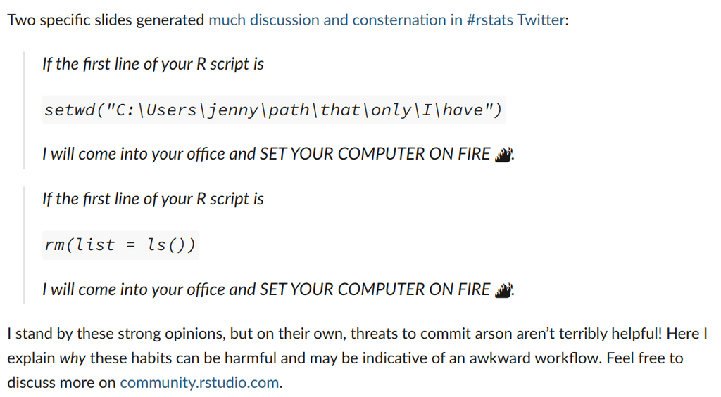

- Note that `setwd()` is not reproducible outside the author’s local machine. Instead, learn to use `here()`’.
- `rm(list = ls())` does not completely remove everything in your environment (e.g., packages).

# Making a project computationally reproducible and self-contained

- Read Jenny Bryan’s wonderful piece on [project-oriented workflow](https://www.tidyverse.org/blog/2017/12/workflow-vs-script/).
- Key idea: separate workflow (e.g., workspace information) from products (code and data)

## `here`: alternative to `setwd()`

- Example

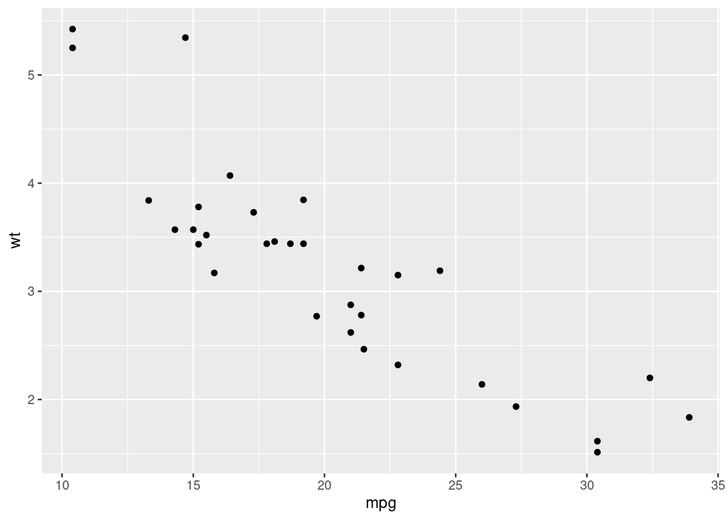

```r
# Old: You won't be able to run this code

ggplot(mtcars, aes(x = mpg, y = wt)) +
  geom_point()
```

```r
ggsave("/home/jae/efficient-reproducible-project-management-in-R/project/outputs/example.png")
```

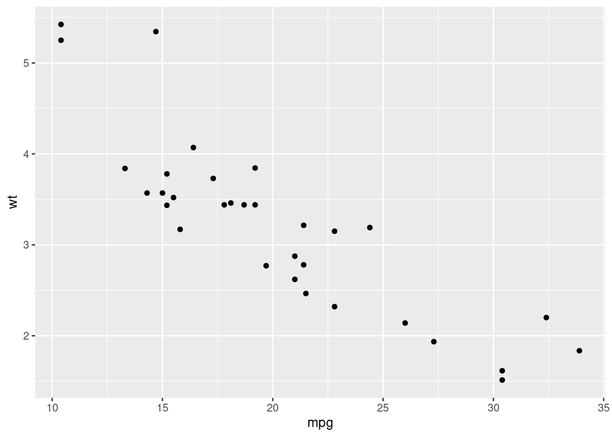

```r
# New: Reproducible

ggplot(mtcars, aes(x = mpg, y = wt)) +
  geom_point()
```

```r
ggsave(here("project", "outputs", "example.png"))
```

- How it works

`here()` function shows what’s the top-level project directory.

```r
here::here()
```

```
## [1] "/home/jae/efficient-reproducible-project-management-in-R"
```

- Build a path including subdirectories

```r
here("project", "outputs")
```

```
## [1] "/home/jae/efficient-reproducible-project-management-in-R/project/outputs"
```

- How `here` defines the top-level project directory. The following list came from [the here package repository](https://github.com/jennybc/here_here)).
  - Note that we already defined an RStudio Project!
- Is a file named .here present?
- Is this **an RStudio Project**? Literally, can I find a file named something like foo.Rproj?
- Is this an R package? Does it have a DESCRIPTION file?
- Is this a remake project? Does it have a file named remake.yml?
- Is this a projectile project? Does it have a file named .projectile?
- Is this a checkout from a version control system? Does it have a directory named .git or .svn? Currently, only Git and Subversion are supported.
- If there’s no match then use `set_here()` to create an empty `.here` file.

**Challenge 1**

1. Can you define computational reproducibility?
2. Can you explain why sharing code and data is not enough for computational reproducibility?

# Making a project usef-friendly

- README.md

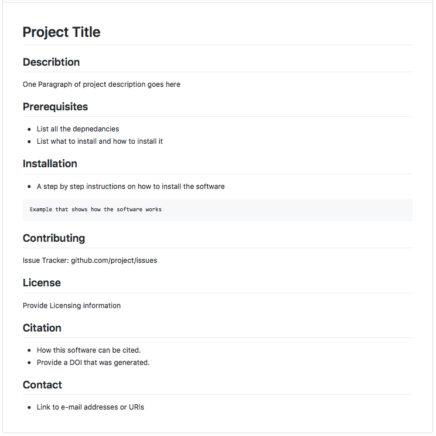

- In this simple markdown file, note some basic information about the project including the structure of the directory.
- This is how I used the README.md file for this workshop. Check out [my GitHub account](https://github.com/jaeyk) to see how I manage my projects.
- Use [binder](https://mybinder.org/) if you want to capture environment. This is especially great if you want to use the code for teaching.